# 5. Multilevel analysis

2023-06-13

> [*Back to content page*](https://flatter11.github.io/6040/)

Learning objective

- Recognize situations where multilevel models are needed to describe the data with a hierarchical structure *dependent data/observations where multilevel model is needed*
- Estimate and interpret effects under hierarchical linear model
- Perform model selection for hierarchical linear model

# 1 Multilevel models

## What is MLM

Class of models which can handle **grouped/clustered data which are not independent** (data with nested structure)

- Different names:
  - Multilevel models (MLM)
  - Hierarchical level model (HLM)
  - Random effects/intercept/slope model
  - Mixed-effects model (fixed + random effects)
- Why MLM?
  - Research question might have a multi-level structure, e.g. household – household members; ward – patients
  - Observations not independent, correlated within units. This violates linear regression assumptions and leads to biased estimates of standard error/uncertainty. Need to allow for dependence for correct inference.
  - Interested in both contextual and individual effects, e.g. want to know difference between countries.
- Consequence of ignoring multi-level structures
  - **Ecological fallacy**: Implications from group not always applicable to individual level
  - **Atomistic fallacy**: May miss important group effects
  - **Inflated type 1 error**: effective sample size < actual sample size (If the observations are dependent, even if u have N samples, u get info from less than N samples). Lead to underestimation of the uncertainty or standard error (p-values too small)
  - **Loss of statistical power**: Reduce signal-to-noise ratio (miss signals from grouping – Sometimes grouping contain information, miss some independent variable/covariant)

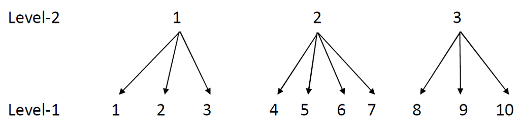

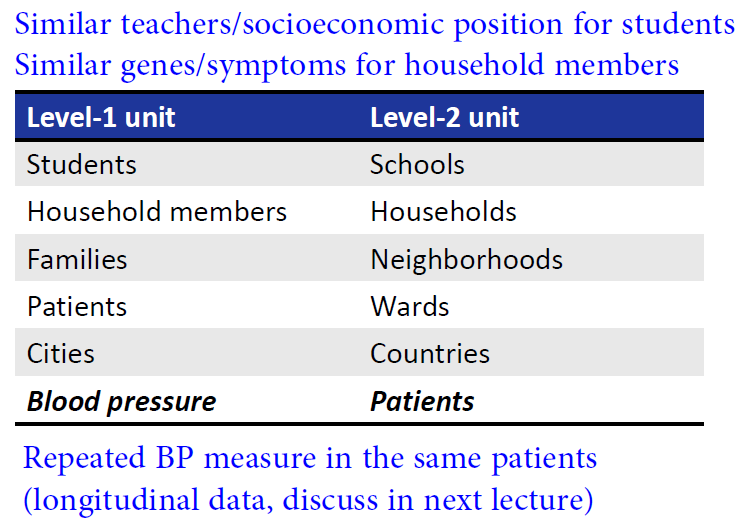

## Model formula

Fixed vs random effects models

1. **Fixed effects**
   - Used when
     1. Interested in **group-level estimates**, especially when the number of groups is small (not practical if large, e.g. thousands of household categories).
     2. Need to adjust for the confounding group-level effects
   - Less efficient as more parameters are needed (Difficult to be significant because u are estimating more things)
   - Assumed conditional independence (After conditioning on grouping, the individuals are independent => error terms are independent)
2. **Random effects**
   - Used when
     - Groups are regarded as a **random sample** from a greater population, especially when the number of groups is large
     - E.g. households are not systematically different but happens randomly (higher/lower income), i.e. different in household 1 and 2 is not research interest
   - More efficient but vulnerable to bias.
   - Assumption: The random effects need to be uncorrelated to the other covariates of the model.

Hierarichical linear model

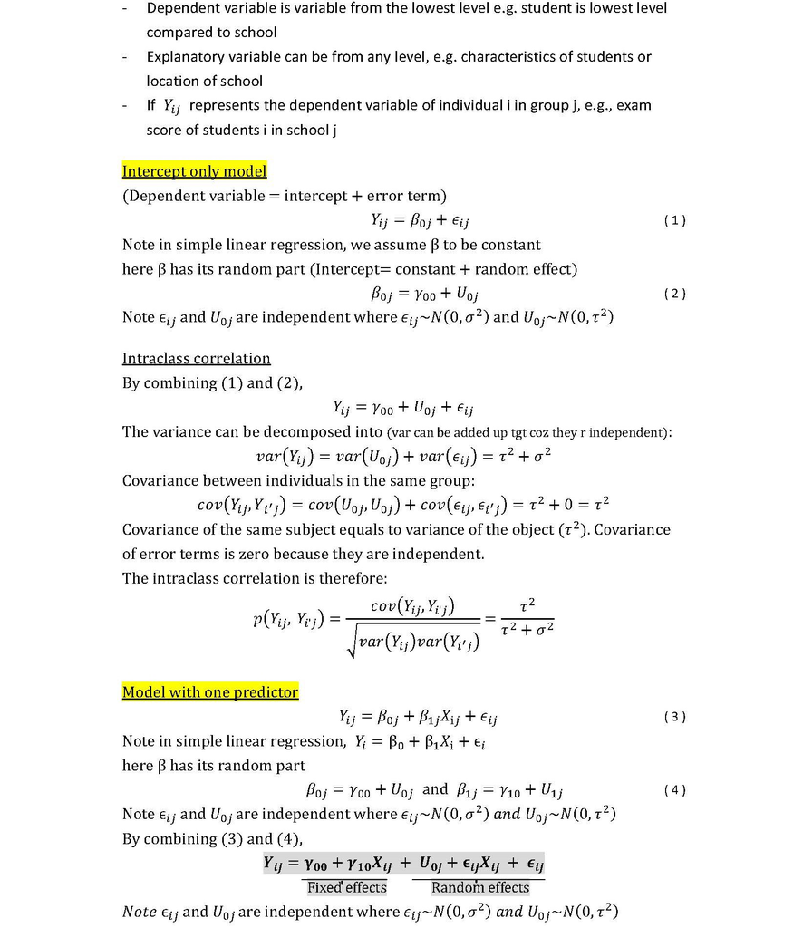

## Estimation procedure for ICC and design effect (R)

Estimate variables

- Need to estimate $\gamma, \sigma^2 \text{ and } \tau^2$. In analysis we want unbiased estimate => use REML but when we do likelihood ratio test => use ML
1. Maximum likelihood (ML)
   - $\hat{\gamma}$ as a function of $\sigma^2 \text{ and } \tau^2$
   - Numerical maximization is needed
   - Used when **likelihood ratio test** is carried out
2. Restricted maximum likelihood (REML)
   - Variance for ML estimate is biased/underestimated (problematic) because the denominator is n instead of (n-1). So REML corrects for the loss in degrees of freedom (using n - p as denominator where p is no. of predictor) and produces **unbiased variance estimates**
   - Preferred when sample size is small (uncertainty is more important)

Estimate ICC and design effect

- **ICC** measures the proportion of variance explained by the between group variance

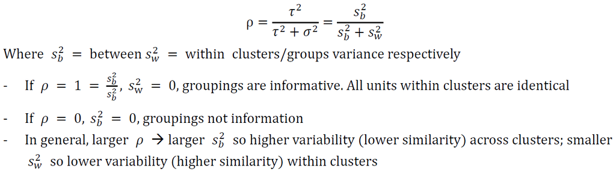

- **Design effect** measure the variance of your dataset compared to variance obtained from simple random sampling

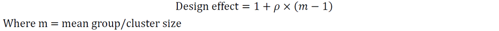

```r
require(ICC)
n.group <- 10
y <- 1:1000 #Type 1. Groupings by sorted values
group <- rep(1:n.group, each=length(y)/n.group) #Group assignments: first 100 to gp1, 2nd 100 to gp 2 etc
rand.y <- sample(y, length(y), replace=F) #Type 2. Grouping randomly assigned/shuffled

## ICC for two groups
ICCest(as.factor(group), y) #ICC close to 1 = grouping is informative
ICCest(as.factor(group), rand.y) #ICC close to 0 = grouping has no information
```

```
## $ICC
## [1] 0.9909009
##
## $LowerCI
## [1] 0.9808451
##
## $UpperCI
## [1] 0.9972585
##
## $N
## [1] 10
##
## $k
## [1] 100
##
## $varw
## [1] 841.6667
##
## $vara
## [1] 91658.25
##
## $ICC
## [1] -0.0001346946
##
## $LowerCI
## [1] -0.005389678
##
## $UpperCI
## [1] 0.02243603
##
## $N
## [1] 10
##
## $k
## [1] 100
##
## $varw
## [1] 83426.79
##
## $vara
## [1] -11.23562
```

# 2 Example

## Background

- Suppose we are interested in the association between age and maternity length of stay (LOS) for mothers after cesarean-section delivery
  - There may also be hospital-level factors (e.g. hospital size) affecting mlos
  - Data were collected from 200 mothers from each of the 12 hospitals. Age: 20-45y. Hospital size: small, medium, large

```r
mlos <- read.csv("Data/examplemlos.csv")
summary(mlos)
mlos$hosp <- as.factor(mlos$hosp) #change hospital from character to factor
```

```
##        id             hosp               size                age
##  Min.   :   1.0   Length:2400        Length:2400        Min.   :20.00
##  1st Qu.: 600.8   Class :character   Class :character   1st Qu.:26.50
##  Median :1200.5   Mode  :character   Mode  :character   Median :32.50
##  Mean   :1200.5                                         Mean   :32.45
##  3rd Qu.:1800.2                                         3rd Qu.:38.60
##  Max.   :2400.0                                         Max.   :45.00
##       los
##  Min.   :1.300
##  1st Qu.:2.737
##  Median :3.165
##  Mean   :3.168
##  3rd Qu.:3.600
##  Max.   :5.070
```

## Basic check of data

Checking association between age and los using different methods, including **plot, regression (+ model diagnostic with residual plot), `xyplot()` in package lattice**

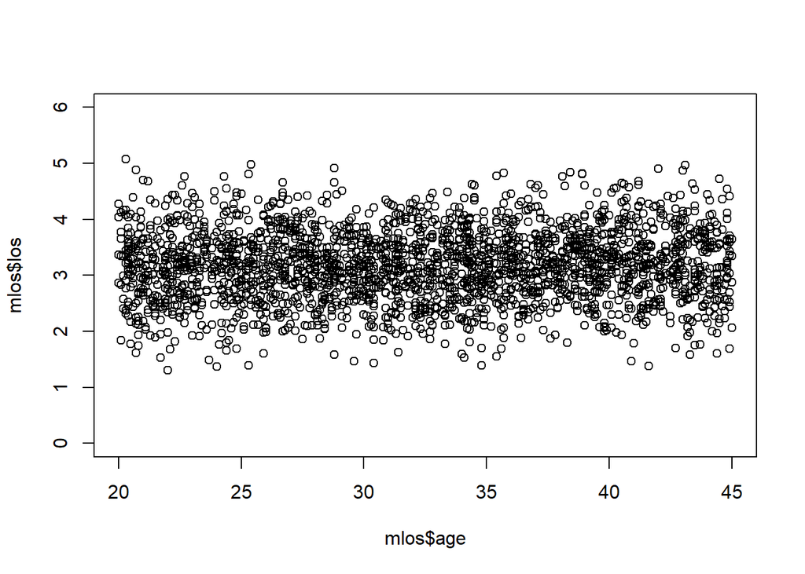

```r
## Simple plot to see if there's relationship between age and los
plot(mlos$age,mlos$los,ylim=c(0,6)) #Plot: No obvious pattern
```

```r
## Simple regression to see if there's relationship between age and los
lm.los <- lm(los~age, data=mlos)
summary(lm.los) #Regression: p-val < 0.05. Age is positively associated with maternity LOS
```

```
##
## Call:
## lm(formula = los ~ age, data = mlos)
##
## Residuals:
##      Min       1Q   Median       3Q      Max
## -1.82652 -0.43361  0.00123  0.42779  1.95409
##
## Coefficients:
##             Estimate Std. Error t value Pr(>|t|)
## (Intercept) 3.029551   0.060594  49.997   <2e-16 ***
## age         0.004254   0.001824   2.332   0.0198 *
## ---
## Signif. codes:  0 '***' 0.001 '**' 0.01 '*' 0.05 '.' 0.1 ' ' 1
##
## Residual standard error: 0.6336 on 2398 degrees of freedom
## Multiple R-squared:  0.002263,   Adjusted R-squared:  0.001847
## F-statistic: 5.439 on 1 and 2398 DF,  p-value: 0.01977
```

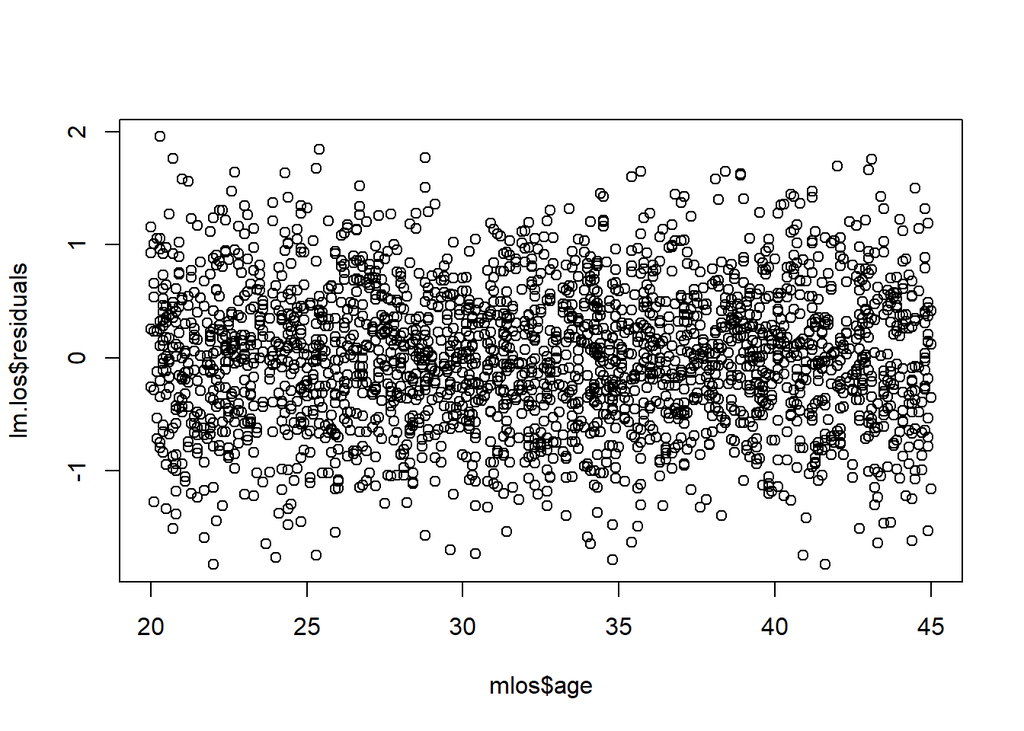

```r
#from the linear regression model without consider potential within-hospital effect

## Perform some model diagnostics (e.g. residual plot) for the linear regression model
plot(mlos$age,lm.los$residuals) #No obvious pattern on age, Centre around 0
```

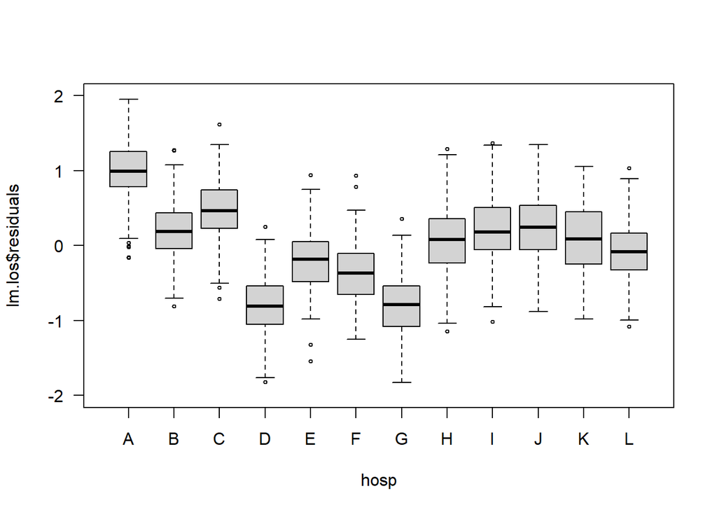

```r
with(mlos, plot(lm.los$residuals~hosp, ylim=c(-2,2),cex=0.5, las=1))
```

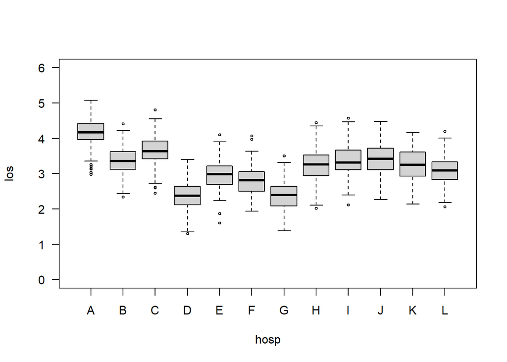

```r
#But can find pattern if boxplot with hospitals. Obvious clustering of residuals by hospitals
#Violated the independence assumption => needa consider hospital effect (e.g. hospital A high; D and G low)
with(mlos, plot(los~hosp,ylim=c(0,6), cex=0.5, las=1))
#Can find similar pattern to previous residual plot.
#Large variation in maternity LOS across hospitals. Multilevel model should describe the data better.

## Use xyplot() to check data
require(lattice)
```

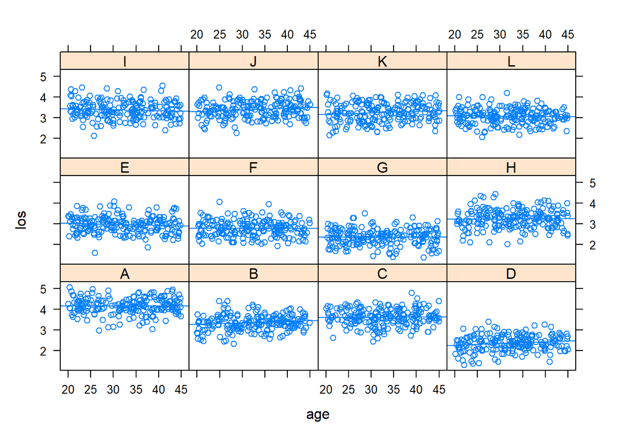

```r
xyplot(los~age|hosp,data=mlos, type=c('p','r')) #"p" for points, "r" for regression line
```

```r
#Hospital A higher (4-5); Hospital G and D lower(2-3).
#Most are horizontal lines -- does age really associates with los after accounting for hospital effects?
```

## Linear mixed model (LMM) / HLM (R)

- Package: lme4
- `lmer(formula, REML=TRUE, offset, subset, data)`
  - **formula**…fixed effects specification similar to lm(), random effects: (RE_var|group)
  - **REML=TRUE** …for restricted maximum likelihood, otherwise maximum likelihood method will be used for the estimation
  - **offset, subset, data** …as usual
- `glmer()` for generalized linear mixed-effects model (GLMM)

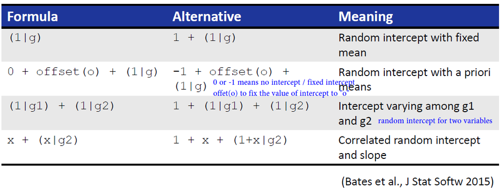

## A. Random intercept model (R)

```r
## Random intercept Model
require(lme4)
hlm.los1 <- lmer(los ~ 1 + (1|hosp), data=mlos)
summary(hlm.los1)
```

```
## Linear mixed model fit by REML ['lmerMod']
## Formula: los ~ 1 + (1 | hosp)
##    Data: mlos
##
## REML criterion at convergence: 2569.9
##
## Scaled residuals:
##     Min      1Q  Median      3Q     Max
## -3.3652 -0.6465  0.0113  0.6714  3.1264
##
## Random effects:
##  Groups   Name        Variance Std.Dev.
##  hosp     (Intercept) 0.2576   0.5076
##  Residual             0.1659   0.4073
## Number of obs: 2400, groups:  hosp, 12
##
## Fixed effects:
##             Estimate Std. Error t value
## (Intercept)   3.1676     0.1468   21.58
```

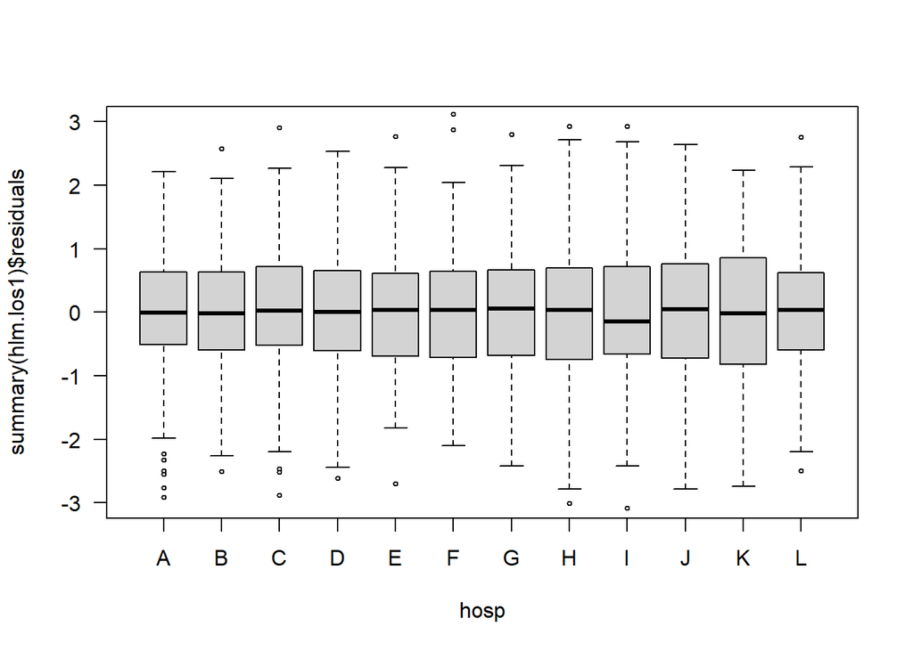

```r
# We have Fixed effect intercept + random effect hospital + error term (residual)
# The estimated overall mean of maternity LOS is 3.2 days
# ICC = 0.2576 / (0.2576+0.1659) = 0.61. Large variation between hospitals (grouping informative)

## Residual after fitting model (accounting for random effect)
with(mlos,plot(summary(hlm.los1)$residuals ~ hosp,ylim=c(-3,3),cex=0.5, las=1))
```

```r
#No obvious clustering of residuals by hospitals (no pattern of residual/error term, the mean is 0)
```

## Bi. Random intercept model with age (R)

```r
## Random intercept model with age
hlm.los2 <- lmer(los ~ age + (1|hosp), data=mlos)
summary(hlm.los2)
```

```
## Linear mixed model fit by REML ['lmerMod']
## Formula: los ~ age + (1 | hosp)
##    Data: mlos
##
## REML criterion at convergence: 2579.7
##
## Scaled residuals:
##     Min      1Q  Median      3Q     Max
## -3.3418 -0.6511  0.0120  0.6675  3.1551
##
## Random effects:
##  Groups   Name        Variance Std.Dev.
##  hosp     (Intercept) 0.2572   0.5071
##  Residual             0.1659   0.4073
## Number of obs: 2400, groups:  hosp, 12
##
## Fixed effects:
##             Estimate Std. Error t value
## (Intercept) 3.115889   0.151502  20.567
## age         0.001594   0.001174   1.357
##
## Correlation of Fixed Effects:
##     (Intr)
## age -0.252
```

```r
# The estimated age effect on maternity LOS is small (0.001594)
# No change in the variance estimates for random effects (still 0.25,0.16). Low explanatory power by age
```

## Bii. Test fixed effects

We should test for fixed effects’ significance.

1. **t-test**
   - Need to calculate the appropriate degree of freedom becoz dataset is dependent
   - Use package `lmerTest` (will replace lmer() in the package `lme4`)
   - Unload the package: `detach("package:lmerTest", unload=TRUE)`
2. **Likelihood ratio test** (preferred)
   - Need to be nested models(?don’t understand)
   - For fixed effect
     - Use likelihood from maximum likelihood estimation (ML instead of REML) `REML=FALSE in lmer())`. Then use `anova()` to do LRT
     - H0: $\gamma_{10}=0$ i.e. whether regression coefficient of predictor (e.g. age) is 0 or not
   - For random intercept effect (see next subpage)
     - Use likelihood from maximum likelihood estimation (ML instead of REML) `REML=FALSE in lmer())` for MLM. Use `logLik()` to obtain the log-likelihood for simple linear regression.
     - H0: $\tau^2=0$ vs H1: $\tau^2>0$

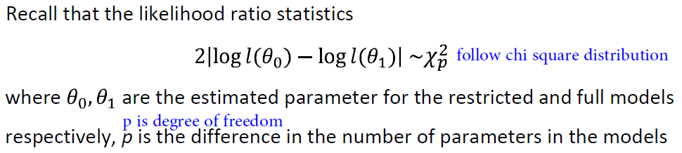

3. **Simulation** (very complicated method)

```r
## T-test
require(lmerTest)
hlm.los2 <- lmer(los ~ age + (1|hosp), data=mlos)
summary(hlm.los2)
# Note df not integer (12.54) becoz dataset is dependent (effective sample size < actual sample size)
# Age is not significant (p-val = 0.175)
```

```
## Linear mixed model fit by REML. t-tests use Satterthwaite's method [
## lmerModLmerTest]
## Formula: los ~ age + (1 | hosp)
##    Data: mlos
##
## REML criterion at convergence: 2579.7
##
## Scaled residuals:
##     Min      1Q  Median      3Q     Max
## -3.3418 -0.6511  0.0120  0.6675  3.1551
##
## Random effects:
##  Groups   Name        Variance Std.Dev.
##  hosp     (Intercept) 0.2572   0.5071
##  Residual             0.1659   0.4073
## Number of obs: 2400, groups:  hosp, 12
##
## Fixed effects:
##              Estimate Std. Error        df t value Pr(>|t|)
## (Intercept) 3.116e+00  1.515e-01 1.254e+01  20.567 4.92e-11 ***
## age         1.594e-03  1.174e-03 2.387e+03   1.357    0.175
## ---
## Signif. codes:  0 '***' 0.001 '**' 0.01 '*' 0.05 '.' 0.1 ' ' 1
##
## Correlation of Fixed Effects:
##     (Intr)
## age -0.252
```

```r
## LRT
#Fit the restricted and full model using ML
hlm.los2.ml <- lmer(los ~ age + (1|hosp), data=mlos, REML=FALSE)
hlm.los20.ml <- lmer(los ~ 1 + (1|hosp), data=mlos, REML=FALSE)
anova(hlm.los20.ml, hlm.los2.ml)
#Age is not significant (p-val = 0.1744)
```

```
## Data: mlos
## Models:
## hlm.los20.ml: los ~ 1 + (1 | hosp)
## hlm.los2.ml: los ~ age + (1 | hosp)
##              npar    AIC    BIC  logLik deviance  Chisq Df Pr(>Chisq)
## hlm.los20.ml    3 2573.8 2591.2 -1283.9   2567.8
## hlm.los2.ml     4 2574.0 2597.1 -1283.0   2566.0 1.8445  1     0.1744
```

## Extra. Test random intercept

We can use LRT to test for random intercept effect too!

```r
## LRT
lm.los20 <- lm(los ~ age, data=mlos) #simple linear regression -- age without random intercept model
#recall that "hlm.los2.ml" is age with random intercept model
lrt <- as.numeric(2*abs(logLik(lm.los20)-logLik(hlm.los2.ml))) #compute likelihood ratio using the formula
pchisq(lrt, df=1, lower.tail=F) #compute p-val
# P-val = 0 so reject null hypothesis. Random intercept model is selected.
```

```
## [1] 0
```